# The BioDT Recreational Potential Model for Scotland

Technical Supplement

Authors

Affiliation

Joe Marsh Rossney

UK Centre for Ecology & Hydrology

Maddalena Tigli

Chris Andrews

Jan Dick

Simon Rolph

Published

June 24, 2025

Modified

July 2, 2025

Abstract

This supplement provides technical details about the Recreational Potential model. This includes a mathematical description of the model, details regarding the source data, and technical aspects of the code.

## 1 Technical description of the model

While there have been several publications citing the RP model, so far none have included a detailed technical description of the model itself.

### 1.1 Presence/absence rasters

We begin by defining some notation.

Let $I : \mathbb{R}^2 \to \{0, 1\}$ be a binary-valued function that maps pairs of coordinates $x \equiv (x_1, x_2) \in \mathbb{R}^2$ to either $0$ or $1$. This is a mathematical representation of a single raster layer in a ‘[one-hot](https://en.wikipedia.org/wiki/One-hot)’ representation, where a value of $I(x) = 1$ indicates presence of a feature at the coordinate $x$, and $I(x) = 0$ indicates absence.

The RP model currently includes 87 features/items grouped into four components (see Section 3). Each of these has its own presence/absence raster. We will therefore introduce two subscript indices and write each layer as $I_{ij}(x)$, where

- $i \in \{1, 2, 3, 4\}$ labels the component to which $I_{ij}$ belongs, as specified in Table 1, and
- $j \in \{1, 2, \ldots, n_i\}$ labels the item/feature within that component, of which there are $n_i$.

As a concrete example, if $j=1$ labels the ‘pond’ item, then $I_{41}(x)$ takes a value of $1$ whenever there is a pond at $x$, and a value of $0$ elsewhere.

| $i$ | Component | Short code |
| --- | --- | --- |
| 1 | Landscape | `SLSRA` |
| 2 | Natural Features | `FIPS_N` |
| 3 | Infrastructure | `FIPS_I` |
| 4 | Water | `Water` |

Table 1: Integer label and short-code for the four components of the RP model.

### 1.2 Proximity contributions

For certain features like rivers and lakes it does not make sense to restrict their contributions to the Recreational Potential to the pixels in which they are present. One does not need to be standing in a lake to appreciate it![^1]

It makes sense to attempt to account for the presence of these features nearby.

Let $\mathcal{P}_{ij} \subset \mathbb{R}^2$ denote the set of coordinates in which the feature $(ij)$ is present, i.e.[^2]

$$\mathcal{P}_{ij} := \left\{ x' \in \mathbb{R}^2 \mid I_{ij}(x') = 1 \right\} \, .
\tag{1}$$

We first compute a ‘distance raster’ in which each pixel is assigned a value that is the (Euclidean) distance to the *nearest* pixel in which the feature $(ij)$ is present,

$$d_{ij}(x) = \min_{x'\in \mathcal{P}_{ij}} \lVert x - x' \rVert_2 \, ,
\tag{2}$$

where $\lVert x - x' \rVert_2 = \sqrt{(x_1 - x'_1)^2 + (x_2 - x'_2)^2}$.

These distances must be mapped to the unit interval $[0, 1]$ such that $0 \mapsto 1$ and $\infty \mapsto 0$, i.e. so that presence of the feature in this pixel results in the highest value of $1$, tailing off to $0$ when the feature is very far away.

There are many different ways to achieve this. Following Paracchini et al. (2014, p. 374 – Eq. 1), the function chosen is a smooth, monotonically decreasing function in the logistic family,

$$u(d_{ij}(x) \,; \alpha, \kappa) = \frac{\kappa + 1}{\kappa + \exp(\alpha \, d_{ij}(x))} \, .
\tag{3}$$

It remains to specify values for the parameters $\kappa$ and $\alpha$, the latter of which is most important since it determines the rate at which the value of $u$ declines as the distance to the nearest feature increases.

The parameters chosen in the original version of this code were[^3]

$$\kappa = 6 \, , \qquad \alpha = 0.01011 \, ,
\tag{4}$$

resulting in a function, Figure 1, that halves at $d\approx200$ (metres) and drops to $0.1$ at $d\approx400$.[^4] At this distance, features with a user-provided score of $10$ (i.e. the highest) would be equivalent to a local feature given a score of $1$ (the lowest). It is safe to assume that at distances greater than this the contribution from the feature would be indiscernible to the user.

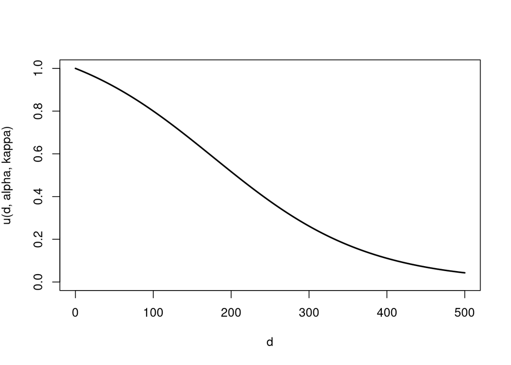

Figure 1: A plot of the function which maps positive distances to the unit interval.

```r
alpha <- 0.01011
kappa <- 6
logistic_func <- function(d) {
    (kappa + 1) / (kappa + exp(alpha * d))
}

d <- seq(0, 500, by = 1)
u <- logistic_func(d)

plot(d, logistic_func(d), ylim=c(0, 1), type="l", lwd=2,
    xlab=expression("d"), ylab=expression("u(d, alpha, kappa)"))
```

### 1.3 Calculation of a single component

As mentioned previously, there are 87 features in total, each of which corresponds to (a) persona score between $0$ and $10$,

$$\rho_{ij} \in \{0, 1, \ldots, 10\} \, ,
\tag{5}$$

and (b) a raster layer $f_{ij}(x)$. For the landscape and natural features components (i.e. $i = 1,2$) the feature rasters are precisely the binary presence/absence rasters discussed previously,

$$f_{ij}(x) = I_{ij}(x) \, , \qquad i = 1, 2 \, .
\tag{6}$$

For the infrastructure and water components ($i=3, 4$) the features rasters contain the proximity contributions described above,

$$f_{ij}(x) = u(d_{ij}(x) \,; \alpha, \kappa) \, , \qquad i = 3, 4 \, .
\tag{7}$$

Each component is calculated as a simple weighted sum of the features contained within it,

$$F_i(x \,; \rho_i) = \sum_{j=1}^{n_i} \rho_{ij} f_{ij}(x) \, ,
\tag{8}$$

where we have permitted $\rho_i$ to denote the set of persona scores $\{\rho_{i1}, \rho_{i2}, \ldots, \rho_{i n_i} \}$ for the $i$-th component.

### 1.4 Domain-dependent rescalings

Let $F \vert_{\mathcal{R}}$ denote the restriction of a function $F$ to a subdomain $\mathcal{R} \subset \mathbb{R}^2$ which defines the ‘region of interest’ in which we wish to compute Recreational Potential. We now define a family of rescaled functions,

$$\hat{F}(x \,; \mathcal{R}) := \frac{F(x) - \min F \big\vert_{\mathcal{R}}}{\max F \big\vert_{\mathcal{R}} - \min F \big\vert_{\mathcal{R}}} \, ,
\tag{9}$$

each of which corresponds to a particular choice of restriction, i.e. a particular region of interest.

Assuming that $F(x)$ is not a constant function on $\mathcal{R}$,[^5] these rescaled functions are ‘normalised’ to the unit interval *within* the region of interest, i.e.

$$\min_{x\in\mathcal{R}} \hat{F}(x \,; \mathcal{R}) = 0 \, , \qquad
\max_{x\in\mathcal{R}} \hat{F}(x \,; \mathcal{R}) = 1 \, .
\tag{10}$$

It is important to be aware that with this approach to rescaling introduces a dependence on the region of interest. That is,

$$\hat{F}(x \,; \mathcal{R}_1) \neq \hat{F}(x \,; \mathcal{R}_2) \, .
\tag{11}$$

Thus, the RP value at any given pixel should be expected to change when a different area is selected, even if the persona and the input data stays the same.

### 1.5 Calculation of Recreational Potential

To compute the Recreational Potential value, the four rescaled components are summed,

$$F_{\mathrm{RP}}(x \,; \rho, \mathcal{R}) = \sum_{i=1}^4 \hat{F}_i(x \,; \rho_i , \mathcal{R}) \, ,
\tag{12}$$

and rescaled $F_{\text{RP}} \longrightarrow \hat{F}_\text{RP}$ using Equation 9 once more (with the same $\mathcal{R}$) so that the result falls in the interval $[0, 1]$.

## 2 Production of input rasters

The process of producing these rasters is currently split into two distinct parts:

1. A **manual part** in which categorical rasters are constructed from raw downloaded datasets using QGIS
2. A **scripted part** in which these categorical rasters are converted into the form required by the model, using `R`.

The scripted part is executed by running `inst/scripts/data_production/main.R` (or the containerised version) with the manually-produced categorical rasters already present. This script mostly just calls functions defined in `R/data_production.R`.

### 2.1 Manipulation in QGIS

#### 2.1.1 Landscape component

The Landscape component raster consists of 40 layers, each representing one of its features (see Section 3 for full list). These features can be grouped into different sub-categories:

- CP (1 feature) : The Country Parks (CP) feature was sourced from NatureScot (2020).
- HNV (1 feature): The High Nature Value farming feature was sourced from European Environment Agency (2023).
- LCM (28 features): The Land Cover Map (LCM) featured were sourced from NatureScot and Space Intelligence (2023).
- NNR (1 feature): The Natural Nature Reserves (NNR) feature was sourced from NatureScot (2022a).
- NP (1 feature): The National Parks (NP) feature was sourced from Stirling Council (2024)
- NR (1 feature): The Nature Reserves (NR) feature was sourced from NatureScot (2021).
- RP (1 feature): The Regional Parks (RP) feature was sourced from NatureScot (2022b).
- RSPB (1 feature): The Protected sites for birds feature was sourced from Royal Society for the Protection of Birds (2024).
- SAC (1 feature): The Special Area for Conservation (SAC) feature was sourced from NatureScot (2023a).
- SPA (1 feature): The Special Protection Areas (SPA) feature was sourced form NatureScot (2023b).
- SSSI (1 feature): The Sites of Specific Scientific Interest (SSSI) feature was sourced from NatureScot (2024).
- SWT (1 feature): The Scottish Wildlife Trust (SWT) feature was sourced from Scottish Wildlife Trust (2024).
- WLA (1 feature): The Wild Land Area (WLA) feature was sourced form NatureScot (2014).

The datasets used for this component were clipped to a Scotland Boundary shapefile (Office for National Statistics, 2018), and they were rasterized to a 20m x 20m resolution.

#### 2.1.2 Natural Features component

The 24 features in this component are grouped into three main categories:

- Landform features (16 features): The landform data was extracted from the Scotland 250K Soils Map. (The James Hutton Institute, 2022). The following methodologies were applied:
  1. Dissolve: the dataset was “dissolved” in QGIS using the “Landform“ attribute, reducing it to 334 unique polygon features.
  2. Reclassification: the 334 landform types were manually grouped into 16 broader categories based on descriptive keywords (e.g. “hills”, “foothills” etc…). See Table 7.
  3. Rasterization: the dataset was converted into a raster at a 20 m x 20 m resolution.
- Slope features (6 features): Slope data were derived from the Copernicus GLO-30 Digital Elevation Model (DEM), a global 30 m resolution dataset (European Space Agency, 2021). The following methodology was applied:
  1. Slope calculation: the DEM was converted into a matching CRS (EPSG: 27700) using Warp (Reproject) using QGIS, with a slope raster calculated using GDAL Slope with its default settings.
  2. Up-sampling: the raster was resampled to a 20 m x 20 m resolution.
- Soil features (2 features): The landform data was derived from the Scotland 250K Soils Map (The James Hutton Institute, 2022) The following methodology was applied:
  1. Initial dissolve: The dataset was “dissolved” by field “genSoilTyp” in QGIS, reducing it to 12 unique attribute values.
  2. Grouping: The values were manually aggregated into two soil classes: organic (peat) and mineral based on the original classifications (see Table 8).
  3. Rasterization: the dataset was converted into a raster at a 20 m x 20 m resolution.

#### 2.1.3 Infrastructure Features component

The 10 features are grouped into three main categories:

- Roads Tracks (5 features): Road Tracks data was sourced from the OS OpenRoads dataset (Ordnance Survey, 2023b). The following methodologies were applied:
  1. Dissolve: The OpenRoads dataset (Ordnance Survey, 2023b) was “dissolved” in QGIS by the field “Road type” and “Tracks”.
  2. Adding access roads: the attribute field “Access roads” from the OSM_Roads dataset (OpenStreetMap, n.d.) was merged into the dissolved dataset.
  3. Rasterization: the combined dataset was rasterized at a 20 m x 20 m resolution.
- Cycle Network (4 features): The National Cycle Network data was sourced from the Sustrans National Cycle Network dataset (Sustrans GIS, 2024). The following methodology was applied:
  1. Dissolve: The dataset was “dissolved” in QGIS using the two attribute fields “Desc_” and “Surface”.
  2. Grouping: The “Desc_” features were then grouped in (1) on road, and (2) off road; whilst the “Surface” features grouped in (3) paved and (4) unpaved. This produced four distinct feature classes
  3. Rasterization: The dataset was converted into raster format at a 20 m x 20 m resolution.
- Local Path Network (1 feature): The “Local Path Network” data was sourced from the Scotland’s Core Paths dataset provided by the Improvement Service (2024). The dataset was converted into raster format at a 20 m x 20 m resolution.

### 2.2 Quantising the slope raster

With one exception, every raster layer produced by the manual process is an integer-valued categorical raster. The single exception is a ‘slope’ raster containing the average absolute gradient $s(x)$ within each pixel.

We use `terra::classify` to quantise this continuous range into six categories according to their steepness (expressed in degrees). These values are based on the six slope intervals from Dick et al. (2022) (expressed in percentages).

$$C_{\text{slope}}(x) = \begin{cases}
1 & &0 \leq s(x) < 1.72 \\
2 & &1.72 \leq s(x) < 2.86 \\
3 & &2.86 \leq s(x) < 5.71 \\
4 & &5.71 \leq s(x) < 11.31 \\
5 & &11.31 \leq s(x) < 16.7 \\
6 & &16.7 \leq s(x) \, .
\end{cases}
\tag{13}$$

### 2.3 Reprojection

The categorical rasters produced in the previous stage do not necessarily share the exact same coordinate grid. They can be coerced to share the same grid using `terra::project`.

We projected all rasters onto a reference raster with the following properties:

- **Coordinate reference system** (CRS): [EPSG:27700](https://epsg.io/27700) (British National Grid)
- **Resolution**: 20 metres x 20 metres
- **Extent**: $(x_\text{min}, x_\text{max}, y_\text{min}, y_\text{max}) = (-10000, 660000, 460000, 1220000)$, which is a rectangular box around Scotland.

We used the ‘nearest’ interpolation mode (`method="near"`) since the data is categorical. The reprojected rasters therefore contain the same set of integer values as the original rasters.

### 2.4 Conversion to one-hot representation

The next stage converts the categorical rasters ($C_i(x) \in \{0, 1, \ldots, n_i\}$ into a set of presence/absence rasters for each feature. These binary-valued rasters are referred to as the *one-hot* representation of the data.

Consider the following categorical raster,

$$C_i = \begin{bmatrix}
\ddots \\
& 1 & 0 & 0 \\
& 2 & 1 & 0 \\
& 2 & 1 & 3 & \\
& & & & \ddots
\end{bmatrix} \, .
\tag{14}$$

The one-hot encoding of this raster is written

$$C_i \overset{\text{one hot}}{\longrightarrow} ( I_{i0}, I_{i1}, I_{i2}, I_{i3}, \ldots) \, ,
\tag{15}$$

where the binary-valued presence/absence rasters are, in this case,

$$\begin{align}
I_{i0} &= \begin{bmatrix}
\ddots \\
& 0 & 1 & 1 \\
& 0 & 0 & 1 \\
& 0 & 0 & 0 & \\
& & & & \ddots
\end{bmatrix} \, , \quad
I_{i1} = \begin{bmatrix}
\ddots \\
& 1 & 0 & 0 \\
& 0 & 1 & 0 \\
& 0 & 1 & 0 & \\
& & & & \ddots
\end{bmatrix} \, , \\
I_{i2} &= \begin{bmatrix}
\ddots \\
& 0 & 0 & 0 \\
& 1 & 0 & 0 \\
& 1 & 0 & 0 & \\
& & & & \ddots
\end{bmatrix} \, , \quad
I_{i3} = \begin{bmatrix}
\ddots \\
& 0 & 0 & 0 \\
& 0 & 0 & 0 \\
& 0 & 0 & 1 & \\
& & & & \ddots
\end{bmatrix} \, .
\end{align}
\tag{16}$$

The implementation of this step involves the use of `terra::lapp` to parallelise the calculation over the spatial domain. In practice we use `NA` instead of `0` to denote absence.

```r
one_hot_pixel <- function(x) {
    out <- matrix(0, nrow = length(x), ncol = length(feature_mapping))
    for (i in seq_along(feature_mapping)) {
        out[, i] <- ifelse(x == as.numeric(feature_mapping[i]), 1, NA)
    }
    return(out)
}

layer <- terra::lapp(
    layer,
    fun = one_hot_pixel,
    filename = outfile,
    overwrite = TRUE,
    wopt = list(
        names = names(feature_mapping),
        datatype = "INT1U"
    )
)
```

**1**

Take a single pixel value (`x`) of a single-layered raster and return the one-hot representation at that point, i.e. a vector of `n_i` values of which up to one is `1` (present) and the remainder are `NA` (absent).

**2**

Apply this function in a vectorised fashion to every pixel of the input faster.

**3**

Write the outputs to `outfile` as they are computed, to reduce memory requirements.

### 2.5 Stacking into component rasters

This stage is nothing more than combining many single-layered rasters files into a single multi-layered raster for each component. Roughly speaking, we do

```r
# Construct a list of rasters from each .tif file in `infiles`
rasters <- lapply(infiles, terra::rast)

# Construct a single multi-layered raster from this list
stacked <- terra::rast(rasters)

# Re-apply layer names
layer_names <- unlist(lapply(rasters, names))
names(stacked) <- layer_names

# Write the combined raster to disk
terra::writeRaster(stacked, outfile)
```

Note that `terra::rast(rasters)` does not preserve layer names when `rasters` is a list of rasters, hence the need for the two lines prior to `writeRaster`.

**A warning about layer names**

It is *very* unfortunate that the names we have used for the layers follow the same format (`filename_i` for integers `i`) as the names that are automatically generated by `terra::rast`. Because of this, if these two lines that re-apply layer names are omitted, it is not obvious that anything is wrong; no error will be thrown and one can go onto compute RP values, since the names are as expected.

However, *the results will be wrong*, since `terra::rast` will apply *the right names in the wrong order*.

Future developers are strongly recommended to fix this problem by using different layer names. This issue and suggested solutions are discussed in depth in the Developers’ Report.

### 2.6 Proximity contributions

This stage applies Equation 2 and Equation 3 to each layer of the Infrastructure and Water components.

In fact Equation 2 is the most challenging computation in the whole processing pipeline, due to the fact that its memory requirements scale poorly with the size of the input raster.

Every single other processing step is entirely local; all of the information required to generate an output value for a pixel at coordinate $x$ is contained in the input pixels at coordinate $x$. This makes it trivial to process the data in chunks, and memory costs scale linearly with the area of the chunks.

In contrast, calculating distance to the nearest feature is strongly non-local; the output value at $x$ is a function of the full set of input values. Naively, the entire raster must be loaded to compute the output at a single location.

To perform this calculation we used [`terra::distance`](https://rspatial.github.io/terra/reference/distance.html). It is not necessarily true that the underlying C++ implementation of `GDALComputeProximity`, which is called by `terra::distance`, actually loads the entire raster into memory immediately. However, for Scotland at 20 metre resolution, we found that the memory requirements for this distance calculation (several 10s of GB) surpass the typical memory available on a standard personal computer by an order of magnitude.

To get around this issue, the original Scotland-wide raster was divided into 20 overlapping spatial ‘windows’. Note that the size of the overlap needed to be at least as large as the effective cutoff distance of 500m. After the distance step was complete within each window, the windows were stitched together, discarding the overlaps.

The distance raster was also truncated at 500m, setting any values above this to `NA` which simply passes through the function applying Equation 3 and ensures that we don’t waste disk space storing high-precision floats that are functionally equivalent to zero.

#### 2.6.1 Visual demonstration

Here we provide a visual demonstration of how a ‘proximity’ raster is obtained from a raster containing just the presence/absence data. The example provided is for the `FIPS_I_RoadsTracks_2` feature layer, which corresponds to ‘A’ roads.

The presence/absence raster traces out the path of the road. The distance from each cell to the nearest present cell is then calculated using the `terra::distance()` function . The resulting raster, labeled *distance* in the example map, contains the distance in meters from the center of each cell to the nearest feature. Application of Equation 3 results in the ‘proximity’ layer.

The three layers can be toggled using the control panel in the top-right corner.

[interactive chart not shown]

## 3 List of items/features

Here we list the full set of 87 items/features that make up the layers of the input rasters, and must be scored by the user to construct a persona.

| Component | Short code | Num. layers | Description |
| --- | --- | --- | --- |
| Landscape | `SLSRA` | 40 | Land cover type, landscape designations and conservation, and farmland of high nature value. |
| Natural Features | `FIPS_N` | 24 | Landform types, soil types and slope. |
| Infrastructure | `FIPS_I` | 10 | Roads, tracks, footpaths and cycle networks. |
| Water | `Water` | 13 | Lakes and rivers. |

### 3.1 Landscape component

| Name | Description |
| --- | --- |
| SLSRA_CP_2 | Country Park |
| SLSRA_HNV_2 | Designated High Nature Value (HNV) farmland |
| SLSRA_LCM_1 | Alpine and subalpine grassland |
| SLSRA_LCM_2 | Arable land and market gardens |
| SLSRA_LCM_3 | Arctic, alpine and subalpine scrub |
| SLSRA_LCM_4 | Bare field or exposed soil |
| SLSRA_LCM_5 | Base-rich fens and calcareous spring mires |
| SLSRA_LCM_6 | Broadleaved deciduous woodland |
| SLSRA_LCM_7 | Built-up area |
| SLSRA_LCM_8 | Coastal dunes and sandy shore |
| SLSRA_LCM_9 | Coastal shingle |
| SLSRA_LCM_10 | Dry grassland |
| SLSRA_LCM_11 | Freshwater |
| SLSRA_LCM_12 | Inland cliffs, rock pavements and outcrops |
| SLSRA_LCM_13 | Lines of trees, small planted woodlands, early-stage woodland and coppice |
| SLSRA_LCM_14 | Littoral sediment or saltmarsh |
| SLSRA_LCM_15 | Mesic grassland |
| SLSRA_LCM_16 | Mixed deciduous and coniferous woodland |
| SLSRA_LCM_17 | Non-native coniferous plantation |
| SLSRA_LCM_18 | Raised and blanket bog |
| SLSRA_LCM_19 | Riverine and fen scrubs |
| SLSRA_LCM_20 | Rock cliffs, ledges and shores |
| SLSRA_LCM_21 | Scots pine woodland |
| SLSRA_LCM_22 | Screes |
| SLSRA_LCM_23 | Seasonally wet and wet grassland |
| SLSRA_LCM_24 | Temperate montane scrub |
| SLSRA_LCM_25 | Temperate shrub heathland |
| SLSRA_LCM_26 | Valley mires, poor fens and transition mires |
| SLSRA_LCM_27 | Windthrown woodland |
| SLSRA_LCM_28 | Woodland fringes and clearings and tall forb stands |
| SLSRA_NNR_2 | National Nature Reserve (NNR) |
| SLSRA_NP_2 | National Park |
| SLSRA_NR_2 | Nature Reserve |
| SLSRA_RP_2 | Regional Park |
| SLSRA_RSPB_2 | Royal Society for the Protection of Birds (RSPB) Reserve |
| SLSRA_SAC_2 | Special Area of Conservation (SAC) |
| SLSRA_SPA_2 | Special Protection Area (SPA) |
| SLSRA_SSSI_2 | Site of Special Scientific Interest (SSSI) |
| SLSRA_SWT_2 | Scottish Wildlife Trust Reserve |
| SLSRA_WLA_2 | Wild Land Areas |

Table 2: Description of items/features in the *Landscape* component.

### 3.2 Natural Features component

| Name | Description |
| --- | --- |
| FIPS_N_Landform_1 | Foothills |
| FIPS_N_Landform_2 | Mountains |
| FIPS_N_Landform_3 | Terraces |
| FIPS_N_Landform_4 | Flood plain |
| FIPS_N_Landform_5 | Beaches or Dunes |
| FIPS_N_Landform_6 | Rocks or Scree |
| FIPS_N_Landform_7 | Depressions |
| FIPS_N_Landform_8 | Hills |
| FIPS_N_Landform_9 | Lowlands |
| FIPS_N_Landform_10 | Rock Walls |
| FIPS_N_Landform_11 | Uplands |
| FIPS_N_Landform_12 | Valley sides |
| FIPS_N_Landform_13 | Valley bottom |
| FIPS_N_Landform_14 | Built-up areas |
| FIPS_N_Landform_15 | Saltings |
| FIPS_N_Landform_16 | Hummocks, mounds or moraines |
| FIPS_N_Slope_1 | No slope |
| FIPS_N_Slope_2 | Gentle slope |
| FIPS_N_Slope_3 | Medium slope |
| FIPS_N_Slope_4 | Steep slope |
| FIPS_N_Slope_5 | Very steep slope |
| FIPS_N_Slope_6 | Extremely steep slope |
| FIPS_N_Soil_1 | Peat or Organic |
| FIPS_N_Soil_2 | Mineral |

Table 3: Description of items/features in the *Natural Features* component.

### 3.3 Infrastructure Features component

| Name | Description |
| --- | --- |
| FIPS_I_LocalPathNetwork_2 | Path |
| FIPS_I_RoadsTracks_4 | Minor or local road |
| FIPS_I_RoadsTracks_2 | A Road |
| FIPS_I_RoadsTracks_1 | Motorway |
| FIPS_I_RoadsTracks_5 | Access roads or Track |
| FIPS_I_RoadsTracks_3 | B Road |
| FIPS_I_NationalCycleNetwork_1 | On Road: Paved Surface |
| FIPS_I_NationalCycleNetwork_2 | Traffic Free: Unpaved Surface |
| FIPS_I_NationalCycleNetwork_3 | Traffic Free: Paved Surface |
| FIPS_I_NationalCycleNetwork_4 | On Road: Unpaved Surface |

Table 4: Description of items/features in the *Infrastructure Features* component.

### 3.4 Water component

| Name | Description |
| --- | --- |
| Water_Lakes_1 | Pond |
| Water_Lakes_2 | Lochan |
| Water_Lakes_3 | Small Lochs |
| Water_Lakes_4 | Medium Lochs |
| Water_Lakes_5 | Large Lochs |
| Water_Lakes_6 | Major Lochs |
| Water_Rivers_1 | Minor river or tributary |
| Water_Rivers_2 | Unnamed minor stream or tributary |
| Water_Rivers_3 | Major river or tributary |
| Water_Rivers_4 | Named minor stream or tributary |
| Water_Rivers_5 | Lake |
| Water_Rivers_6 | Tidal river or estuary |
| Water_Rivers_7 | Canal |

Table 5: Description of items/features in the *Water* component.

## 4 List of data sources

Data sources used for the creation of the underlaying raster datasets.

| Name | Component | Description | Source | Attribute statement | Conditions of use | Data Owner/IPR | Version |
| --- | --- | --- | --- | --- | --- | --- | --- |
| Scotland Boundary | NA | Shapefile of the Scotland boundary - NUTS level1 | Office for National Statistics, 2018 | Contains public sector information licensed under the Open Government Licence v3.0. Contains OS data © Crown copyright and database right 2024 | Freely available for any use (public domain or CC0) | UK Govt. | Jan-18 |
| Core paths network | FIPS_I | shapefile containing the core path network | Improvement Service, 2024 | Contains public sector information licensed under the Open Government Licence v3.0. | NA | Improvement Service | 15/02/2024 |
| Roads | FIPS_I | Shapefile contains road types | Ordnance Survey, 2023b | Contains Ordnance Survey data licensed under the Open Government Licence v3.0. | Freely available for any use (public domain or CC0) | Ordnance Survey (OS) | Oct-23 |
| Tracks | FIPS_I | Shapefile containing road types within OpenStreetMap (OSM) filtered for tracks. | OpenStreetMap, n.d. | Map data copyrighted OpenStreetMap contributors and available from https://www.openstreetmap.org | Freely available for any use (public domain or CC0) | Ordnance Survey (OS) | NA |
| National Cycle Network | FIPS_I | shapefile containing the National Cycle Network | Sustrans GIS, 2024 | Contains public sector information licensed under the Open Government Licence v3.0. | NA | NA | 18-Feb-24 |
| Landform classes from Scotland Soil Map | FIPS_N | A shapefile containing polygons of the soil types and landorm at a 250k:1 scale | The James Hutton Institute, 2022 | National Soil Map of Scotland v1.4 copyright and database right The James Hutton Institute 2024. Used with the permission of The James Hutton Institute. All rights reserved. Any public sector informat… | Freely available with obligation to quote the source | James Hutton Institute | 1.4 |
| Slope | FIPS_N | Created from Copernicus GLO-30 Digital Elevation Model | European Space Agency, 2021 | European Space Agency, Sinergise (2021). Copernicus Global Digital Elevation Model. Distributed by OpenTopography. https://doi.org/10.5069/G9028PQB. Accessed: 2024-02-15 | Freely available with obligation to quote the source | ESA | 01/01/2011 - 07/01/2015 |
| Soilclasses from Scotland Soil Map | FIPS_N | A shapefile containing polygons of the soil types and landorm at a 250k:1 scale | The James Hutton Institute, 2022 | National Soil Map of Scotland v1.4 copyright and database right The James Hutton Institute 2024. Used with the permission of The James Hutton Institute. All rights reserved. Any public sector informat… | Freely available with obligation to quote the source | James Hutton Institute | 1.4 |
| Spatial inventory of UK waterbodies | Water | Lakes | Taylor, 2021 | Contains data supplied by UK Centre for Ecology & Hydrology licensed under the Open Government Licence v3.0. | Freely available with obligation to quote the source | UKCEH | v3.6 |
| OS Open Rivers | Water | Rivers | Ordnance Survey, 2023a | Contains Ordnance Survey data licensed under the Open Government Licence v3.0. | Freely available with obligation to quote the source | Ordnance Survey (OS) | 2.3 - (04/2023) |
| Land Cover Map | SLSRA | EUNIS L2 Raster containing pixels of land cover habitat type | NatureScot and Space Intelligence, 2023 | Maps and data created by Space Intelligence with input and support from NatureScot , © SNH | Freely available with obligation to quote the source | UKCEH | 2022 |
| NNR | SLSRA | Shapefile containing areas designated as NNR | NatureScot, 2022a | Contains public sector information licensed under the Open Government Licence v3.0. | Freely available for any use (public domain or CC0) | Nature Scot | 24/07/2023 |
| National Parks | SLSRA | Shapefile containing Scotlands National Parks | Stirling Council, 2024 | © Scottish Government, contains Ordnance Survey data © Crown copyright and database right 2024. | Freely available for any use (public domain or CC0) | Scottish Govt. | 20/02/2023 |
| NR | SLSRA | Shapefile containing areas designated as Nature Reserves | NatureScot, 2021 | Contains public sector information licensed under the Open Government Licence v3.0. | Freely available for any use (public domain or CC0) | Nature Scot | 24/07/2023 |
| Regional Park | SLSRA | Shapefile containing areas designated as Regional Park | NatureScot, 2022b | Contains public sector information licensed under the Open Government Licence v3.0. | Freely available for any use (public domain or CC0) | Nature Scot | 24/07/2023 |
| RSPB Reserves | SLSRA | Shapefile containing RSPB reserves | Royal Society for the Protection of Birds, 2024 | Data reproduced with the permission of RSPB. © Crown Copyright. Ordnance Survey licence number 100021787 (2024) | Freely available with obligation to quote the source | RSPB | NA |
| SAC | SLSRA | Shapefile containing areas designated as Special Areas of Convervation (SAC) | NatureScot, 2023a | Contains public sector information licensed under the Open Government Licence v3.0. | Freely available for any use (public domain or CC0) | Nature Scot | 29-Aug-23 |
| SPA | SLSRA | Shapefile containing areas designated as SPA | NatureScot, 2023b | Contains public sector information licensed under the Open Government Licence v3.0. | Freely available for any use (public domain or CC0) | Nature Scot | 24/07/2023 |
| SSSI | SLSRA | Shapefile containing areas designated as SSSI | NatureScot, 2024 | Contains public sector information licensed under the Open Government Licence v3.0. | Freely available for any use (public domain or CC0) | Nature Scot | 15/02/2024 |
| SWT Reserves | SLSRA | Shapefile containing Scottish Wildlife Trust (SWT) reserves | Scottish Wildlife Trust, 2024 | Scottish Wildlife Trust | Freely available with obligation to quote the source | Scottish Wildlife Trusts | NA |
| Wildland | SLSRA | Shapefile containing areas designated as Wildland | NatureScot, 2014 | Contains public sector information licensed under the Open Government Licence v3.0. | Freely available for any use (public domain or CC0) | Nature Scot | 2014 (24/7/2024) |
| CountryParks | SLSRA | Shapefile containing areas designated as CountryParks | NatureScot, 2020 | Contains public sector information licensed under the Open Government Licence v3.0. | Freely available for any use (public domain or CC0) | Nature Scot | 24/07/2023 |
| High Nature Value (HNV) farmland | SLSRA | Shapefile containing HNV farmland land parcels | European Environment Agency, 2023 | N/A available via EEA data portal under open access (ODC-by) | Freely available for any use (public domain or CC0) | EEA | NA |

Table 6: List of data sources.

## 5 Reclassification tables

### 5.1 Landform

| Landform | Reclassification |
| --- | --- |
| Undulating foothills and valley sides with gentle and strong slopes: non-rocky | Foothills |
| Valley sides with steep and very steep slopes: non- to moderately rocky | Valley sides |
| Lowland with dry ridges and wet hollows with gentle and strong slopes: slightly rocky | Lowlands |
| Undulating lowlands and uplands with gentle and strong slopes: non-rocky | Undulating ground |
| Hills with strong slopes | Hills |
| Ridged hills with gentle to strong slopes: very rocky | Hills |
| Mountains with gentle and strong slopes: non- to very rocky | Mountains |
| Undulating hills with gentle and strong slopes: moderately rocky | Undulating ground |
| Lowlands with complex gentle and strong slopes: moderately rocky | Lowlands |
| Rugged dissected lowlands and hills with gentle and strong slopes: very rocky | Hills |
| Hill sides with valley sides and hills with steep and very steep slopes: moderately and very rocky | Hills |
| Foothills with strong and steep slopes | Foothills |
| Hills and valley sides and undulating lowlands with gentle to steep slopes | Hills |
| Hill sides with steep and very steep slopes: moderately and very rocky | Hills |
| Lowlands with gentle slopes: non-rocky | Lowlands |
| Hill and valley sides with gentle and strong slopes | Valley sides |
| Hills and valley sides with steep and very steep slopes: non-rocky | Hills |
| Undulating uplands with complex gentle slopes: slightly to moderately rocky | Uplands |
| Hills and valley sides with gentle to steep slopes: slightly to moderately rocky | Hills |
| Hills and undulating lowlands with gentle and strong slopes: moderately rocky | Hills |
| Hills with simple strong and steep slopes | Hills |
| Hills and valley sides with gentle and strong slopes: non-rocky | Hills |
| Mountains with gentle to very steep slopes: slightly to very rocky | Mountains |
| Hills with gentle and strong slopes: slightly rocky | Hills |
| Hill sides and undulating lowlands with strong and steep slopes: moderately rocky | Hills |
| Hill sides with gentle and strong slopes: slightly and moderately rocky | Hills |
| Hills with complex strong slopes: moderately rocky | Hills |
| Hills with complex gentle to strong slopes: slightly to moderately rocky | Hills |
| Drumlins and undulating lowlands with gentle and strong slopes | Undulating ground |
| Lowlands with gentle and strong slopes: non- and slightly rocky | Lowlands |

[output cut: 304 more lines]

Table 7: Reclassification of the Natural Features component (landform layers) baed on data extracted from The James Hutton Institute (2022).

### 5.2 Soil

| **Reclassification** | **genSoilTyp** |
| --- | --- |
| Organic | Peaty podzols, Peaty gleys, Peat, |
| Mineral | Mineral podzols, Mineral gleys, Brown soils, Montane soils, Immature soils, Alluvial soils, Calcareous soils |

Table 8: Reclassification of the Natural Features component (soil layers) based on The James Hutton Institute (2022).

### 5.3 Rivers

| **Class** | **Example search terms or process** |
| --- | --- |
| Major river or tributary | Specific e.g. “Tay”, “Spey” etc… |
| Tidal river or estuary | taken from dataset attribute “form” |
| Minor river or tributary | e.g. “River”, “Abhainn”, “Uisge” |
| Named minor stream or tributary | e.g. “Allt”, “Alltan”, “Burn”, “Feadan”, “Sruth”, “Caochan” |
| Unnamed minor stream or tributary | Waterways with no names |
| Canal | taken from dataset attribute “form” |
| Lake | taken from dataset attribute “form” |

Table 9: Example search terms for the reclassification of the Water component (river layers) based on Ordnance Survey (2023a). The full table can be downloaded as a `.csv` by clicking on this link.

### 5.4 Lakes

| Class | size (ha) |
| --- | --- |
| Pond | $<0.2$ |
| Lochan | $0.2-2$ |
| Small loch | $2-10$ |
| Mediun loch | $10-100$ |
| Large loch | $100-500$ |
| Major loch | $>500$ |

Table 10: Reclassification of the Water component (lakes layers) based on data from Taylor (2021).

## Access to code & data

Code for the Recreational Potential model is available as an R Package hosted on GitHub at https://github.com/BioDT/uc-ces-recreation. These reports relate specifically to the [version 1.0 release](https://github.com/BioDT/uc-ces-recreation/releases/tag/v1.0), which is also available on Zenodo at https://doi.org/10.5281/zenodo.15705544.

The model requires some input data that is too large to be bundled in with the package, but which can be downloaded from Dropbox after package installation using `biodt.recreation::download_data()`. This data is also included in the Zenodo listing.

The source for these documents and this website can be found at https://github.com/BioDT/ces-recreation-reports.

## Funding

Funding for OpenNESS came from the European Community’s Seventh Framework Programme (FP7/2007-2013) under grant agreement no 308428, OpenNESS Project (Operationalisation of Natural Capital and Ecosystem Services: From Concepts to Real-world Applications.)

Funding for BioDT came from the European Union’s Horizon Europe Research and Innovation Programme under grant agreement No 101057437 (BioDT project, https://doi.org/10.3030/101057437). Views and opinions expressed are those of the author(s) only and do not necessarily reflect those of the European Union or the European Commission. Neither the European Union nor the European Commission can be held responsible for them.

Funding for SPEAK came from the Natural Environment Research Council – Growing Shoots Partnership and application co-creation bursary. NE/Y005805/1 _Growing Shoots.

## CRediT statement

**JMR:** software; visualisation; writing. **MT:** software; visualisation; writing. **CA:** conceptualisation; data curation; funding acquisition; software. **JD:** conceptualisation; funding acquisition; project administration. **SR:** funding acquisition; software.

## Acknowledgements

We wish to acknowledge significant contributions to a previous version of the Recreational Potential model by Will Bolton. JMR would also like to thank Tomáš Martinovič for assisting with understanding the requirements of BioDT.

We are very grateful to all the participants of the SPEAK project which this output is based on including: Alastair Leaver, Alice MacSporran, Brian Cassidy, Chris Pollock, David Giles, Jean Cowie, Joanna Gilliatt, Justyna Olszewska, Laura Taylor, Maddi Bunker, Rebecca MacLennan, S Mayes, Shaila Rao, Steve MacKinnon and Tom Gebbie, Active Stirling. We are equally grateful to an additional 18 participants who preferred to remain anonymous.

## Correspondence

- `{jand,chan}@ceh.ac.uk` for enquiries relating to the BioDT or SPEAK projects, or ongoing and future work.
- `chan@ceh.ac.uk` for enquiries relating to the data sources and QGIS processing.
- `{joemar,madtig}@ceh.ac.uk` for enquiries relating to the code and anything else appearing in the technical supplement and/or developer’s report.
- `simrol@ceh.ac.uk` for enquiries relating to the biodiversity component of the BioDT project.

## References

Dick, J., Andrews, C., Orenstein, D. E., Teff-Seker, Y., & Zulian, G. (2022). A mixed-methods approach to analyse recreational values and implications for management of protected areas: A case study of cairngorms national park, UK. *Ecosystem Services*, *56*, 101460. https://doi.org/10.1016/j.ecoser.2022.101460

European Environment Agency. (2023). *High Nature Value (HNV) farmland. 2012 accounting version, Nov. 2017*. https://www.eea.europa.eu/en/datahub/datahubitem-view/1bd26e8f-8ea0-45e0-b6bf-9ed2baff5d28?activeAccordion=1070000%2C61.

European Space Agency. (2021). *Copernicus Global Digital Elevation Model*. https://portal.opentopography.org/raster?opentopoID=OTSDEM.032021.4326.3.

Improvement Service. (2024). *Core Paths - Scotland [Web Feature Service]*. https://data.spatialhub.scot/dataset/core_paths-is.

NatureScot. (2014). *Wild land areas 2014*. https://opendata.nature.scot/datasets/snh::wild-land-areas-2014/about; NatureScot.

NatureScot. (2020). *Country parks*. https://opendata.nature.scot/datasets/snh::country-parks/about; NatureScot.

NatureScot. (2021). *Nature reserves*. https://opendata.nature.scot/datasets/snh::nature-reserves/about; NatureScot.

NatureScot. (2022a). *National nature reserves*. https://opendata.nature.scot/datasets/snh::national-nature-reserves/about; NatureScot.

NatureScot. (2022b). *Regional parks*. https://opendata.nature.scot/datasets/snh::regional-parks/about; NatureScot.

NatureScot. (2023a). *Special areas of conservation (SAC)*. https://opendata.nature.scot/datasets/snh::special-areas-of-conservation/about; NatureScot.

NatureScot. (2023b). *Special protection areas (SPA)*. https://opendata.nature.scot/datasets/snh::special-protection-areas/about; NatureScot.

NatureScot. (2024). *Sites of special scientific interest (SSSI)*. https://opendata.nature.scot/datasets/snh::sites-of-special-scientific-interest/about; NatureScot.

NatureScot and Space Intelligence. (2023). *Scotland habitat and land cover map – 2022*. https://spatialdata.gov.scot/geonetwork/srv/api/records/8462f345-6e9c-45de-b1d2-665a55b9d74a; NatureScot.

Office for National Statistics. (2018). *NUTS, level 1 (January 2018) Boundaries UK BFC*. https://geoportal.statistics.gov.uk/datasets/e9cfbf2e478a481bb367eb2f2891d504_0/about.

OpenStreetMap. (n.d.). *Map of Scotland*. https://www.openstreetmap.org.

Ordnance Survey. (2023a). *OS Open Rivers. Version 2.3*. https://osdatahub.os.uk/downloads/open/OpenRivers.

Ordnance Survey. (2023b). *OS Open Roads*. https://osdatahub.os.uk/downloads/open/OpenRoads.

Paracchini, M. L., Zulian, G., Kopperoinen, L., Maes, J., Schägner, J. P., Termansen, M., Zandersen, M., Perez-Soba, M., Scholefield, P. A., & Bidoglio, G. (2014). Mapping cultural ecosystem services: A framework to assess the potential for outdoor recreation across the EU. *Ecological Indicators*, *45*, 371–385. https://doi.org/10.1016/j.ecolind.2014.04.018

Royal Society for the Protection of Birds. (2024). *RSPB reserves*. https://opendata-rspb.opendata.arcgis.com/datasets/6076715cb76d4c388fa38b87db7d9d24/explore; RSPB Open Data Portal.

Scottish Wildlife Trust. (2024). *Scottish wildlife trust reserve boundaries (public view)*. https://scottish-wildlife-trust-swt.opendata.arcgis.com/datasets/SWT::scottish-wildlife-trust-reserve-boundaries-public-view/about; Scottish Wildlife Trust Open Data Portal.

Stirling Council. (2024). *National parks scotland*. https://opendata.scot/datasets/stirling+council-open+data+-+national+parks+scotland/; Stirling Council Open Data.

Sustrans GIS. (2024). *National Cycle Network (Public)*. https://data-sustrans-uk.opendata.arcgis.com/datasets/Sustrans-UK::national-cycle-network-public-1/about.

Taylor, P. J. (2021). *Spatial inventory of UK waterbodies*. https://doi.org/10.5285/b6b92ce3-dcd7-4f0b-8e43-e937ddf1d4eb; NERC EDS Environmental Information Data Centre.

The James Hutton Institute. (2022). *National Soil Map of Scotland. Version 1.4*. https://spatialdata.gov.scot/geonetwork/srv/eng/catalog.search#/metadata/B7E65842-C041-4950-BF0C-3AF06C2DBAE7.

## Footnotes

[^1]: Indeed this is true for almost every type of feature, but these proximity contributions were only computed for roads/paths and water features.
[^2]: The right-hand-side of Equation 1 can be read as “The set of all 2d coordinates $x'$ for which the condition $I_{ij}(x') = 1$ is satisfied.”
[^3]: The provenance of these values, which date back to the [earliest version of the code](https://github.com/BioDT/uc-ces/commit/5c5961376df6753725e634378fa709dac1050ff6), has been lost. The precision with which $\alpha$ is given is a particular curiosity.
[^4]: Note that this does not exhibit the classic ‘S’ shape of logistic curves since the domain is restricted to the positive real line (distances are non-negative!).
[^5]: If $F(x)$ is constant in the region of interest then the right-hand-side of Equation 9 diverges and $\hat{F}$ is undefined.

## Copyright

BioDT and the UK Centre for Ecology & Hydrology, 2025